# 40.09. Сравнительный расчёт чувствительности сборок TEPC-2–TEPC-7

## Аннотация

Выполнен вычислительный эксперимент для шести четырёхэлектродных сборок, центры которых автор исследования выбрал на наружной поверхности индивидуальной модели. Цель — определить, как изменение удельного сопротивления каждого целого компартмента влияет на передаточный импеданс и как это влияние зависит от фоновых сопротивлений остальных компартментов. Рассматриваются мягкие ткани, сердце целиком и оба лёгких как одна область. Геометрия, костный компартмент и контактные условия фиксированы. Компартмент — выделенная область модели с одним общим значением удельного сопротивления. Электрическая задача решается методом конечных элементов (FEM, finite element method).

**Текущий результат: полный перебор и проверка покрытия завершены; покрытие требует уточнения из-за невыполненных критериев.** Численное ранжирование новых сборок в этой редакции представлено в разделе результатов с отдельным заключением о покрытии. Подготовка входов и проверка программ не подтверждают физическую адекватность модели.

Основная серия содержит **1134 рассчитанных состояния**: шесть сборок, по 125 узлов полного перебора и 64 дополнительных состояния в центрах ячеек параметрической сетки. До основной серии рассчитаны ещё 78 контрольных состояний для проверки производных. Основная серия перебирает сетку значений удельного сопротивления. Для построения контактов диаметром 5 мм отдельно потребовалось локально уточнить сетку около выбранных точек. Проверка покрытия диапазона сопротивлений и проверка пространственной дискретизации имеют разное назначение.

## 1. Исследовательский вопрос и границы сравнения

Для каждой сборки требуется получить три знаковые производные передаточного импеданса по удельному сопротивлению, их диапазоны и зависимость от остальных сопротивлений. Следующий вопрос — сохраняется ли преимущество одной сборки по чувствительности к выбранному компартменту при изменении всего набора тканевых параметров. Выбор целевого компартмента оставлен исследователю: сердечная, лёгочная и мягкотканная чувствительность имеют разные практические назначения.

В текущей постановке удельное сопротивление меняется одинаково во всех элементах выбранного компартмента. Перемещения границ, неоднородные локальные изменения, смещение и изменение радиуса эквивалентной сердцу сферы не моделируются. Состояния не описывают временную траекторию сердечного или дыхательного цикла. Все сочетания литературных границ образуют область проверки модели; не утверждается, что каждое сочетание встречается у живого человека с одинаковой вероятностью.

Геометрический источник — используемая в ветке 40.05 модель Nix, основанная на КТ с ручной сегментацией автора. По подтверждённому контексту проекта исходная КТ получена на вдохе. На данном этапе не выполняются повторная сегментация или независимая проверка анатомических границ. Метки конечных элементов рассчитаны по тканевым поверхностям; искусственные продолжения рук являются геометрическим допущением модели.

**Рабочие допущения.** Мягкотканный компартмент заменяет неоднородные мягкие ткани одним скалярным сопротивлением, включая искусственные продолжения рук в данной модели. Маска сердца представляет эффективную смесь крови и миокарда без известной доли крови. Оба лёгких имеют одно общее сопротивление. Ткани считаются изотропными, а электрическая задача — линейной и резистивной. Эти допущения ограничивают перенос вычисленных показателей на физиологические измерения.

## 2. Источники расположений и условия эксперимента в статье

Источник схем — работа M. Metshein и соавторов *Study of Electrode Locations for Joint Acquisition of Impedance- and Electro-cardiography Signals* (EMBC, 2021). В статье обозначение TEPC относится к вариантам грудного размещения электродов. Авторы использовали электроды 3M 2228 и частоту импедансного измерения **100 кГц**; электроды ЭКГ были физически отделены от импедансных. Обозначения RA, LA и LL относятся к ЭКГ и не добавляются к четырём контактам настоящей FEM-модели. [Полный текст, с. 7265, разделы II.A–B](https://www.paperhost.org/proceedings/embs/EMBC21/files/1232.pdf#page=2).

В текущей серии из статьи заимствована идея расположений. Частота модели остаётся **50 кГц** для сопоставимости с ранее подготовленным исследованием сопротивлений. По отдельному решению автора все контакты имеют диаметр **5 мм**. Размер проводящей площадки TEPC и её контактный импеданс в проверенном тексте статьи не установлены. Упоминание ширины 5 мм в статье относится к другим, брюшным схемам AEPC-1–AEPC-4 и не обосновывает выбранный здесь размер TEPC. [С. 7266, раздел II.D и рис. 3–4](https://www.paperhost.org/proceedings/embs/EMBC21/files/1232.pdf#page=3).

Таким образом, исследуется перенос выбранных схем на индивидуальную геометрию при общих контактных условиях. Результаты нельзя объявлять воспроизведением экспериментальных величин или выводов статьи. Для отдельной серии на 100 кГц потребуется заново вычислить литературные опорные сопротивления на этой частоте и оформить новый паспорт расчёта.

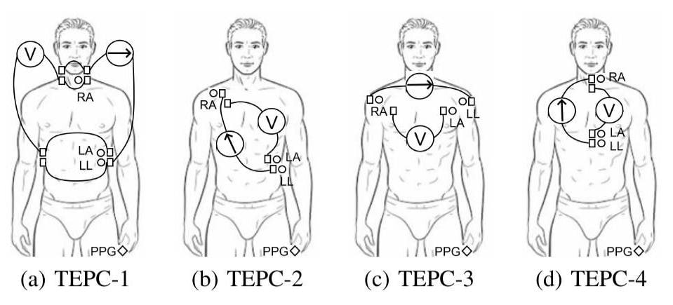

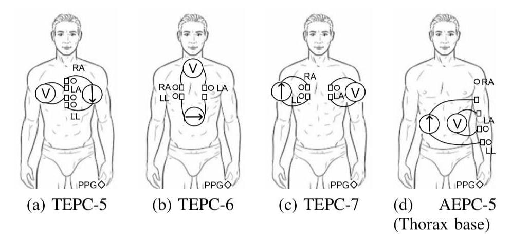

**Рисунки 1–2.** Схемы, приложенные автором задания, соответствующие рис. 3–4 статьи. Квадраты обозначают позиции импедансных электродов, но не устанавливают форму проводящей площадки. Из восьми показанных схем в архиве представлены TEPC-2–TEPC-7; TEPC-1 и AEPC-5 в расчёт не включены, поскольку их координаты не переданы. [Источник схем, с. 7266](https://www.paperhost.org/proceedings/embs/EMBC21/files/1232.pdf#page=3).

## 3. Авторские координаты и электрические пары

Архив содержит шесть самостоятельных JSON-файлов. Каждый файл задаёт четыре центра в миллиметрах и их роли. Роли читаются по именам, а не по порядку полей JSON. Ток вводится через I+ и выводится через I−; регистрируется разность потенциалов V+ минус V−. Полярность потенциальной пары принята из JSON: на опубликованных схемах она не подписана.

Исходные байты архива и файлов сохранены; контактные площадки строятся отдельно на расчётной границе. Численные координаты в JSON являются результатом ручного выбора на отображаемой поверхности, а не опубликованными метрическими координатами и не измерением фактического расположения электродов на добровольце. Модель хранит отдельно запрошенный центр, ближайшую точку расчётной поверхности и центр площади реализованного контакта.

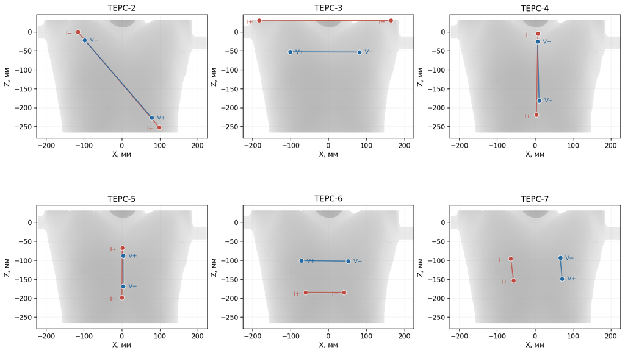

**Рисунок 3.** Проекции шести переданных расстановок на поверхность модели. Красные маркеры — токовые электроды, синие — потенциальные; размеры маркеров увеличены для чтения. Линии соединяют электрические пары и не изображают проводящие пути в тканях. Оси сохраняют координаты исходной модели. Из-за проекции наложение маркера на силуэт само по себе не подтверждает принадлежность поверхности.

Сходство с рисунками установлено на уровне назначения пар. Метрическое и анатомическое совпадение с публикацией не подтверждено. В частности, диагональ TEPC-2 и сторона токовой пары TEPC-7 зависят от принятого соглашения о сторонах модели. Токовые точки TEPC-3 находятся у верхней границы усечённой модели; принадлежность расчётной границе не доказывает соответствие кожной поверхности плеча. Координаты и роли не отражались и не переставлялись автоматически: расчёт относится к переданным JSON, а не к восстановленным по рисунку положениям.

| Сборка | Роль | X, мм | Y, мм | Z, мм |
| --- | --- | --- | --- | --- |
| TEPC-2 | I+ | 97,955 | -77,667 | -251,479 |
| TEPC-2 | V+ | 78,833 | -88,833 | -226,667 |
| TEPC-2 | V− | -97,861 | -74,925 | -22,000 |
| TEPC-2 | I− | -116,069 | -66,062 | -0,432 |
| TEPC-3 | I+ | -183,000 | 24,000 | 30,500 |
| TEPC-3 | V+ | -101,129 | -78,189 | -52,992 |
| TEPC-3 | V− | 81,740 | -75,169 | -53,649 |
| TEPC-3 | I− | 163,961 | 23,995 | 29,875 |
| TEPC-4 | I+ | 3,845 | -93,155 | -218,833 |
| TEPC-4 | V+ | 10,782 | -95,118 | -181,294 |
| TEPC-4 | V− | 6,752 | -53,750 | -26,139 |
| TEPC-4 | I− | 7,472 | -43,894 | -4,663 |
| TEPC-5 | I+ | 1,038 | -77,735 | -66,697 |
| TEPC-5 | V+ | 3,000 | -85,967 | -88,267 |
| TEPC-5 | V− | 3,292 | -95,141 | -168,333 |
| TEPC-5 | I− | 0,305 | -96,052 | -198,571 |
| TEPC-6 | I+ | -60,000 | -100,000 | -184,833 |
| TEPC-6 | V+ | -71,295 | -97,021 | -100,705 |
| TEPC-6 | V− | 51,651 | -89,317 | -102,174 |
| TEPC-6 | I− | 40,975 | -96,556 | -185,025 |
| TEPC-7 | I+ | -56,676 | -101,024 | -153,400 |
| TEPC-7 | V+ | 71,442 | -90,308 | -148,750 |
| TEPC-7 | V− | 66,286 | -85,915 | -93,415 |
| TEPC-7 | I− | -63,786 | -97,033 | -96,033 |

**Таблица 1.** Запрошенные центры электродов, мм. Это исходные данные для построения площадок; при оценке геометрического качества используются их полные, не округлённые значения.

## 4. Контактная модель и геометрическая проверка

Для каждой сборки создаются четыре отдельные поверхностные площадки полной электродной модели (CEM, complete electrode model). Каждый электрод эквипотенциален; удельный контактный импеданс связывает ток через поверхность с разностью потенциалов металла и ткани. Площадь равна $A=\pi d^2/4=19{,}635$ мм², где $d=5$ мм — выбранный автором диаметр. Поправка 90% не применяется: сохранена площадь прежнего варианта дисков 5 мм.

Удельный контактный импеданс одинаков для всех контактов: $z_c=1{,}59155\cdot10^{-4}$ Ом·м². Это фиксированное модельное значение из прежнего сравнения, а не измеренный параметр данных электродов. Даже при нулевом суммарном токе потенциальный электрод остаётся частью CEM. В модели присутствуют только четыре контакта текущей сборки; одновременное подключение всех шести сборок не предполагается.

Площадка растёт по связанным граничным треугольникам вокруг центра. Её площадь измеряется по тому набору граней, который действительно использует EIDORS. Общие узлы между электродами запрещены. До допуска к расчёту проверяются расстояние исходной точки до поверхности, смещение центра площади и отношение фактической площади к целевой. Приняты технические пределы: 5 мм, 2,5 мм и 0,95–1,50 соответственно. Они выявляют грубую ошибку размещения; сами по себе не обеспечивают сходимость решения по размеру конечных элементов. Фактические значения приведены ниже, чтобы широкий верхний предел площади не скрывал несовпадение контактов.

| Сборка | Геометрический и матричный контроль | Причина отказа |
| --- | --- | --- |
| TEPC-2 | пройден | — |
| TEPC-3 | пройден | — |
| TEPC-4 | пройден | — |
| TEPC-5 | пройден | — |
| TEPC-6 | пройден | — |
| TEPC-7 | пройден | — |

Максимальная относительная норма расхождения с матрицей EIDORS — 1,18e-17; установленный предел — 10⁻¹².

По 24 контактам: площадь 19,644–20,155 мм²; наибольшее смещение центра площади 0,628 мм; наибольшее расстояние исходной точки до границы 0,625 мм.

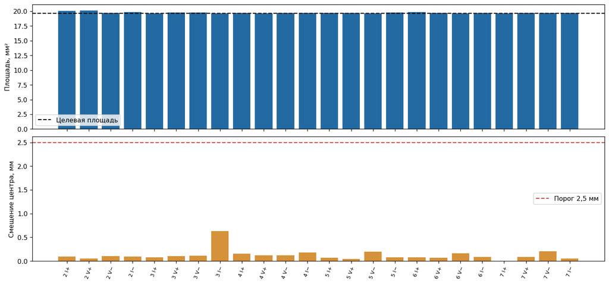

**Рисунок 4а.** Фактические площади и смещения центров контактных площадок. Пороговые линии относятся только к техническому контролю текущей дискретизации.

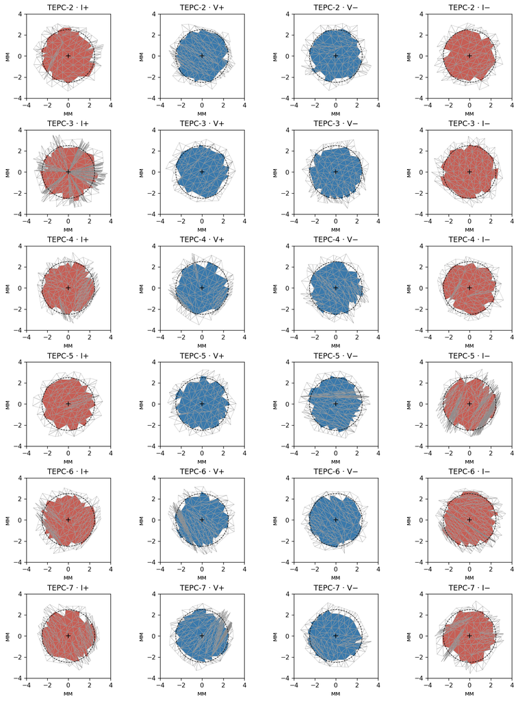

**Рисунок 4б.** Реальные контактные пятна на расчётной границе в локальной плоской проекции. Крест — исходный центр; пунктир — окружность радиусом 2,5 мм; окрашены фактически включённые в CEM треугольники. Проекция показывает форму дискретизации и не изменяет геометрию при решении.

Первичная проверка на прежней сетке из 752 827 узлов и 4 358 825 тетраэдров выявила неприемлемые площадки у TEPC-3 и TEPC-6. У токовых контактов TEPC-3 смещение центра площади достигло 12,22 и 22,03 мм; у одного контакта TEPC-6 — 4,20 мм. У одного контакта TEPC-3 площадь составила 45,0 мм² при целевых 19,635 мм². При таких отклонениях расчёт характеризовал бы другое размещение и другие размеры контактов. Отрицательный результат сохранён отдельно и не включён в основной перебор.

Для устранения этой ошибки проведено согласованное деление рёбер в окрестности 8 мм от каждого выбранного центра. Длина рёбер граничных треугольников в этих окрестностях уменьшена до 1 мм. Каждое выбранное ребро разделялось во всех прилежащих тетраэдрах и граничных треугольниках, а новые узлы ставились в его середину. Исходные вершины не перемещались; поверхность тела и разделение тканей сохранились. Проверены положительность объёмов всех тетраэдров, согласованность полной границы и сохранение объёмов пяти групп элементов. Наибольшее изменение суммарного объёма группы из-за округления составляет менее $2\cdot10^{-7}$ мм³.

Уточнённая модель содержит **791 141 узел и 4 448 426 тетраэдров**. Для неё заново собраны все объёмные матрицы; контактные матрицы прежней сетки не используются. Все шесть новых сборок сравниваются на одной уточнённой модели. Совместное численное ранжирование со старыми сборками этапов 40.05–40.08 потребует общей дискретизации или отдельного обоснования малости различия между сетками. Обозначение локального уточнения «1 мм» не означает, что все тетраэдры тела имеют размер 1 мм или что пространственная сходимость чувствительности доказана.

## 5. Диапазоны удельного сопротивления

Диапазоны перенесены из зафиксированного литературного профиля этапа 40.08. Опорные значения получены на 50 кГц из модели дисперсии Gabriel в базе IT’IS, версия 5.0. Для мягких тканей границы образованы значениями мышцы и жировой ткани, для сердца — крови и миокарда, для лёгких — состояний сниженного и повышенного воздухонаполнения. Кости имеют постоянное сопротивление кортикальной кости. [База IT’IS 5.0, DOI 10.13099/VIP21000-05-0](https://itis.swiss/virtual-population/tissue-properties/downloads/database-v5-0).

| Компартмент | Нижняя граница | Верхняя граница | Шаг по ρ | Узлов |
| --- | --- | --- | --- | --- |
| Мягкие ткани | 2,8423 | 23,1086 | 5,0666 | 5 |
| Сердце целиком | 1,4269 | 5,1168 | 0,9225 | 5 |
| Лёгкие | 3,8173 | 9,7413 | 1,4810 | 5 |
| Кости | 48,4451 | 48,4451 | — | фиксировано |

**Таблица 2.** Общие сопротивления для сравнения всех сборок. Единица — Ом·м; для перехода к Ом·см значение умножается на 100. Приведённые границы — выбранная область эффективных модельных параметров между литературными опорами. Они не являются доверительными интервалами для человека, исчерпывающим диапазоном литературы или амплитудами пульсовых изменений.

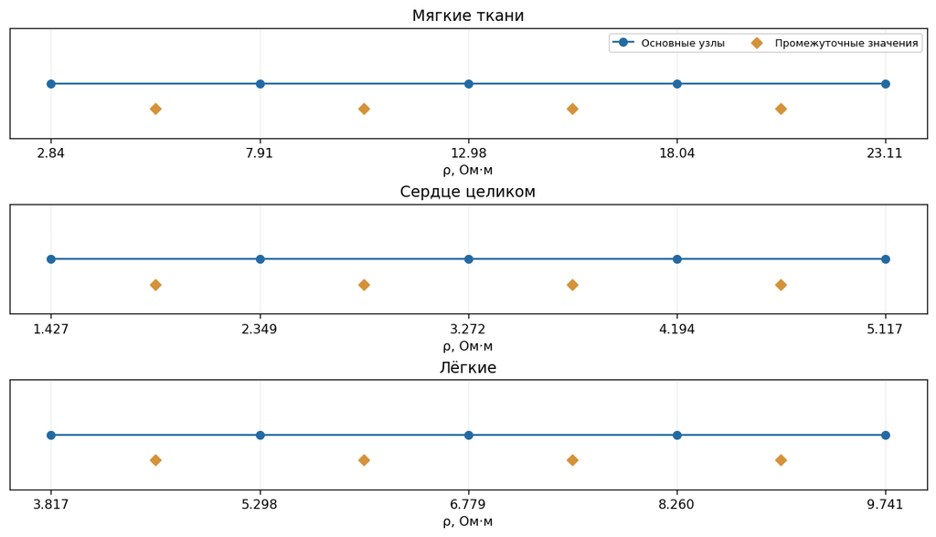

**Рисунок 5.** Пять равномерных узлов по ρ и четыре промежуточных значения каждой оси. Равномерность задана по сопротивлению; соответствующие проводимости $\sigma=1/\rho$ распределены неравномерно. Для костного компартмента варьирование не проводится.

## 6. Производная по целому компартменту

В каждом состоянии решаются прямая задача с фактической токовой парой и взаимная задача, в которой токовая и потенциальная пары меняются ролями. Нормировка на 1 А служит определению передаточного импеданса; это не заявленная амплитуда экспериментального или разрешённого тока через человека.

Матрица линейной задачи имеет вид

$$K(\boldsymbol\rho)=C+\sum_k\frac{1}{\rho_k}G_k,\qquad K u=q_I,\qquad K v=q_V,$$

где $C$ — матрица контактных условий; $G_k$ — матрица объёмного вклада компартмента при единичной проводимости; $u$ и $v$ — решения прямой и взаимной задач; $q_I$ и $q_V$ — нормированные схемы возбуждения. Сумма включает также фиксированный костный компартмент. Для мягких тканей складываются объёмные матрицы туловища и искусственных продолжений рук. Опорный потенциал фиксируется одинаково в обеих задачах. Передаточный импеданс равен $Z=q_V^{\mathsf T}u$.

Чувствительность к сопротивлению целого компартмента вычисляется аналитически через сопряжённое решение:

$$S_k(\boldsymbol\rho)=\frac{\partial Z}{\partial\rho_k}=-\frac{1}{\rho_k^2}\frac{\partial Z}{\partial\sigma_k}=\frac{1}{\rho_k^2}v^{\mathsf T}G_k u,$$

где $S_k$ имеет размерность Ом/(Ом·м), то есть м⁻¹. Это знаковая производная по одному равномерно изменяемому параметру всей области. Объём, положение и неоднородность электрического поля уже участвуют в $G_k$, $u$ и $v$. Деление на объём изменило бы исследовательский вопрос и в текущем сравнении не применяется.

Знак $S_k$ показывает направление изменения Z при росте ρ в принятой полярности. При смене полярности потенциальной пары знаки Z и всех производных меняются вместе; модули и доли чувствительности остаются прежними. Для малых изменений можно использовать $\Delta Z\approx\sum_k S_k\Delta\rho_k$. Для конечного перехода через весь диапазон отклик рассчитывается разностью двух прямых решений, а не умножением одной производной на ширину диапазона.

## 7. Численные показатели для сравнения сборок

В дополнение к $S_k$ рассчитываются показатели

$$B_k^{(\rho)}=|S_k|w_k,\qquad Q_k=\frac{|S_k|w_k}{\sum_j|S_j|w_j},\qquad w_k=\rho_{k,\max}-\rho_{k,\min},$$

где $w_k$ — общий для всех сборок литературный масштаб изменения параметра, $B_k^{(\rho)}$ — локальный линейный масштаб отклика в омах, $Q_k$ — безразмерная доля целевого отклика среди трёх варьируемых компартментов. При нулевом знаменателе доля не определена; численная проверка должна сообщить об этом.

Высокое $B_k^{(\rho)}$ означает большой абсолютный отклик на общий масштаб изменения целевого параметра. Высокое $Q_k$ означает сравнительно малое влияние остальных варьируемых параметров на этой же шкале. Большая доля может сочетаться с очень малым абсолютным сигналом, поэтому оба показателя рассматриваются совместно. Доли не являются вероятностями происхождения сигнала; кость в знаменатель не входит, поскольку её сопротивление фиксировано.

Для каждой сборки сохраняются минимумы показателей по проверенным состояниям и пары различий между сборками при одинаковом наборе сопротивлений. Максимизация минимума даёт отдельное предпочтение по абсолютной чувствительности и по доле целевого отклика. Минимум по конечному набору точек ещё не является строгой нижней границей во всём непрерывном диапазоне. Без модели приборной ошибки и отдельной проверки установки электродов эти показатели не определяют клинически оптимальную сборку.

## 8. Полный перебор и критерий достаточного покрытия

Основная сетка содержит $5^3=125$ состояний каждой сборки. В неё вложена более редкая сетка $3^3=27$, что позволяет сравнить выводы до и после сгущения без повторного решения в общих узлах. Кроме того, во всех $4^3=64$ центрах ячеек выполняется независимый прямой FEM-расчёт. Его производные сопоставляются с трёхлинейной интерполяцией производных по окружающим узлам; промежуточные решения не используются при построении этой интерполяции.

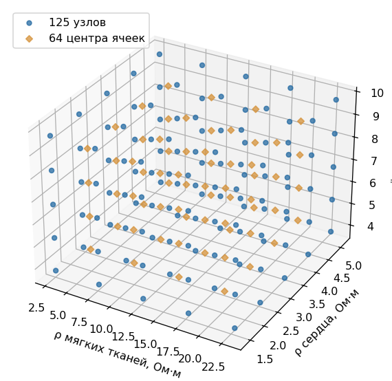

**Рисунок 6.** Полная сетка сопротивлений и промежуточные проверочные состояния. Каждая точка задаёт одновременно сопротивления мягких тканей, сердца и лёгких. Один и тот же набор состояний используется для всех сборок.

Четыре уровня проверки разделены по назначению:

1. **Корректность электрического расчёта.** Для каждой новой контактной модели проверяется совпадение матрицы EIDORS с суммой объёмных и контактной матриц с относительной нормой ошибки не выше $10^{-12}$. Решатель дополнительно проверяет невязку и взаимность прямого и обратного передаточного импеданса.
2. **Независимый контроль производных.** До основного перебора в средней точке диапазонов выполняются центральные разности по каждому целому компартменту с двумя шагами: 0,1% и 0,05% ширины его диапазона. Проверяется совпадение с аналитической производной и устойчивость при уменьшении шага; допуск равен 0,5% большего модуля сравниваемых производных плюс $10^{-8}$ м⁻¹. Это проверка вычисления производной, а не замена полного перебора и не физиологическая амплитуда.
3. **Точность интерполяции и различий.** Для каждой сборки и компартмента допускается ошибка производной не выше $0{,}05|S_{\mathrm{FEM}}|+0{,}005\max_{\mathrm{сетка}}|S|$; для доли $Q$ — абсолютная ошибка 0,005. Для каждой из 15 пар сборок отдельно проверяется разность модулей производных и разность долей. Порог парной ошибки равен 5% модуля прямой разности плюс малая абсолютная добавка: $10^{-4}$ максимального модуля S среди сборок в том же состоянии или $10^{-4}$ для Q. Сходные ошибки двух сборок могут взаимно компенсироваться, поэтому индивидуального контроля недостаточно.
4. **Устойчивость предпочтений.** Между сетками 3 и 5 узлов, а затем после добавления проверочных состояний изменение минимального $B^{(\rho)}$ не должно превышать 1% большего из двух минимумов; изменение минимального Q — 0,0005. Множества предпочтительных сборок должны совпадать. Зона практически неразличимых предпочтений задаётся отдельно: $10^{-4}$ относительно лучшего минимального $B^{(\rho)}$ и $10^{-4}$ абсолютно для минимального Q. Для неразличимых пар не требуется устойчивость знака разности, но проверка ошибки остаётся обязательной.

Все пороги являются заранее выбранными численными критериями этого исследования, а не метрологической точностью прибора. Покрытие признаётся достаточным **только на проверенных состояниях**, если выполнены все условия. При нарушении хотя бы одного условия сохраняются проверки с невыполненными критериями; следующий уровень сетки выбирается после их разбора. Расчёт 9³ состояний не запускается автоматически. Отсутствие нарушений в центрах ячеек не доказывает отсутствие узкого экстремума в другой точке, а проверка по ρ не заменяет пространственную сходимость FEM.

## 9. Порядок воспроизведения и выходы

Пути к установленным MATLAB и Python сохранены в отдельной локальной конфигурации, не включаемой в переносимый код. Вычислительная часть ноутбука содержит один явный выбор действия. Вызов использует уже подготовленную локальную уточнённую модель. По умолчанию выполняется только проверка входных файлов. Последовательность работы: проверить геометрию и контактные матрицы; выполнить контрольную серию производных; после её успешного завершения запустить основной перебор; затем выполнить анализ и обновить читательский отчёт. Большая серия не запускается простым открытием ноутбука или выполнением его в режиме проверки.

Результаты этапа 40.08 сохранены отдельно. Серия 40.09 не заменяет его входы и результаты. Расчёты выполняются последовательно через действующую точку входа MATLAB/EIDORS и Python-решатель с четырьмя потоками. Проверенные завершённые блоки при повторном запуске используются повторно; незавершённые попытки сохраняются отдельно. Несовпадение исходных файлов, кода или контрольных сумм останавливает продолжение, чтобы не объединять несовместимые результаты.

Основные выходы — передаточный импеданс, знаковые производные по ρ, абсолютные и относительные показатели чувствительности, конечные отклики между границами каждого диапазона при всех фиксированных сочетаниях остальных параметров, таблицы парных различий, проверки интерполяции и устойчивости предпочтений. Полные поля потенциала для всех состояний не сохраняются: для текущего вопроса достаточно интегральных производных по целым компартментам.

| Этап | Текущее состояние |
| --- | --- |
| Исходные координаты | 6 файлов, 24 центра; целостность проверена |
| Геометрия и CEM | проверены |
| Основные файлы запуска | 150 блоков; 1134 состояния |
| Контроль производных | результат сохранён; см. отдельный протокол |
| Основная серия | анализ сохранён |
| Полная пространственная сходимость и физическая валидация | не выполнены |

### Результаты основной серии

| Критерий | Результат |
| --- | --- |
| Полнота матрицы | выполнен |
| Интерполяция производных | не выполнен |
| Интерполяция долей | не выполнен |
| Парные разности чувствительности | не выполнен |
| Парные разности долей | не выполнен |
| Устойчивость знаков парных различий | не выполнен |
| Устойчивость минимумов | выполнен |
| Устойчивость предпочтительных множеств | выполнен |

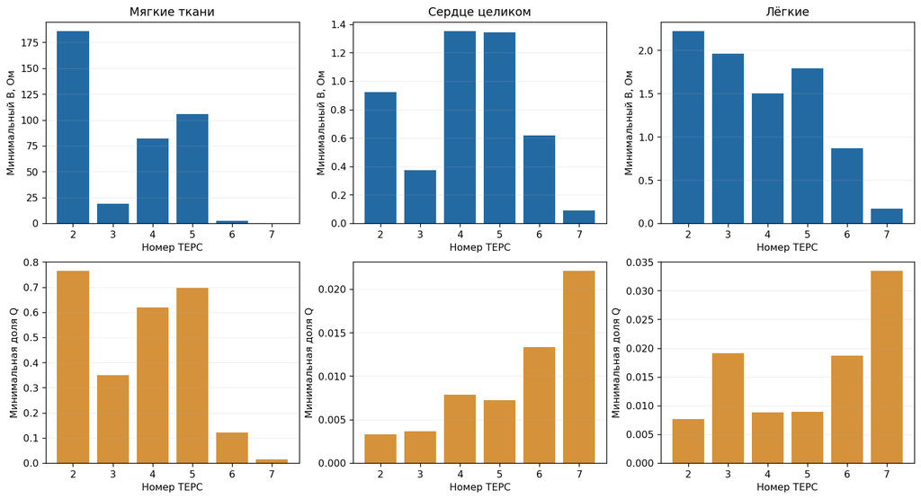

**Рисунок 7.** Минимальные показатели по 125 узлам и 64 проверочным состояниям каждой сборки. Это минимумы конечной выборки состояний, а не доказанные нижние границы на непрерывной области. B характеризует абсолютный масштаб, Q — долю целевой чувствительности.

| Сборка | Компартмент | Минимальный B, Ом | Минимальный Q |
| --- | --- | --- | --- |
| TEPC-2 | Мягкие ткани | 185,639 | 0,763961 |
| TEPC-2 | Сердце целиком | 0,923688 | 0,00329865 |
| TEPC-2 | Лёгкие | 2,21917 | 0,00761706 |
| TEPC-3 | Мягкие ткани | 19,0206 | 0,348871 |
| TEPC-3 | Сердце целиком | 0,37356 | 0,00363609 |
| TEPC-3 | Лёгкие | 1,96195 | 0,0190969 |
| TEPC-4 | Мягкие ткани | 82,0655 | 0,618235 |
| TEPC-4 | Сердце целиком | 1,34957 | 0,00785393 |
| TEPC-4 | Лёгкие | 1,50041 | 0,00879152 |
| TEPC-5 | Мягкие ткани | 105,355 | 0,697152 |
| TEPC-5 | Сердце целиком | 1,34312 | 0,00724918 |
| TEPC-5 | Лёгкие | 1,78962 | 0,00889391 |
| TEPC-6 | Мягкие ткани | 2,6763 | 0,121066 |
| TEPC-6 | Сердце целиком | 0,616723 | 0,013309 |
| TEPC-6 | Лёгкие | 0,870358 | 0,0187149 |
| TEPC-7 | Мягкие ткани | 0,0307509 | 0,0152597 |
| TEPC-7 | Сердце целиком | 0,0899879 | 0,0220767 |
| TEPC-7 | Лёгкие | 0,167462 | 0,033405 |

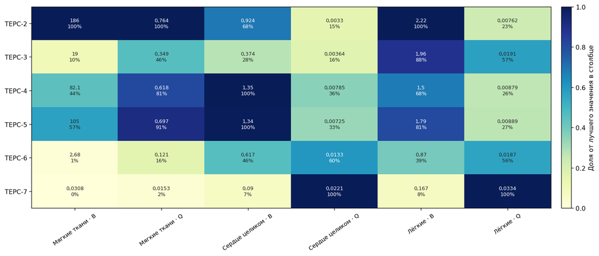

**Рисунок 8.** Матрица минимальной чувствительности с цветовым градиентом. Верхняя строка каждой ячейки — исходное значение B, Ом, либо Q; нижняя — процент от наибольшего значения в том же столбце. Тёмный цвет означает большее значение для выбранного компартмента и показателя. Нормирование выполнено отдельно по столбцам, поэтому цвет B нельзя количественно сравнивать с цветом Q или с другим компартментом.

### Предварительная практическая интерпретация

- **Мягкие ткани.** TEPC-2 имеет наибольшие значения минимальных $B$ (186 Ом) и $Q$ (0,764). Если цель состоит в регистрации изменения сопротивления всего мягкотканного компартмента, TEPC-2 является первым кандидатом среди шести рассчитанных вариантов.
- **Сердечная область: абсолютный отклик.** Наибольший минимальный $B$ получен у TEPC-4 (1,35 Ом). TEPC-5 почти совпадает с ним; разница составляет около 0,48% от результата TEPC-4. Поскольку часть критериев попарной точности не выполнена, эти две сборки следует считать близкими кандидатами до дополнительного сгущения по ρ и пространственной проверки.
- **Сердечная область: избирательность.** Наибольший минимальный $Q$ получен у TEPC-7 (0,022), но её сердечный $B$ равен только 0,09 Ом. Высокая доля возникла при малом абсолютном отклике всех компартментов; одна эта доля не делает TEPC-7 лучшей для измерения сердца.
- **Лёгкие: абсолютный отклик.** Наибольший минимальный $B$ получен у TEPC-2 (2,22 Ом); второе значение — у TEPC-3 (1,96 Ом). TEPC-2 является кандидатом для максимального модельного отклика лёгких.
- **Лёгкие: избирательность.** TEPC-7 имеет наибольший минимальный $Q$ (0,033), но её лёгочный $B$ равен 0,167 Ом. TEPC-3 сочетает существенно больший $B$ (1,96 Ом) с меньшей, но сравнительно высокой долей Q; поэтому она представляет более содержательный компромисс для последующей проверки отношения сигнал/шум.

В пределах этих шести вариантов широкая диагональная трасса TEPC-2 связана с большим абсолютным вкладом мягких тканей и лёгких, а центральная продольная TEPC-4 — с большим абсолютным вкладом сердечной области. Поперечная TEPC-7 повышает относительную долю сердца и лёгких главным образом за счёт снижения общего абсолютного отклика. Это наблюдение модели, а не доказанный общий закон геометрии электродов.

Из этой серии нельзя вывести универсальное правило «сдвигать электроды к плечам», «сближать их» или «увеличивать площадь». Координаты не изменялись систематически по одному фактору, а площадь всех контактов была одинаковой. Увеличение площади обычно уменьшает контактную составляющую импеданса и меняет распределение плотности тока, но не обязано увеличивать тканевую производную или её избирательность. Эти факторы требуется проверить отдельным вычислительным планом при фиксированных остальных параметрах.

Не все критерии достаточности покрытия выполнены. Указанные предпочтения являются предварительными; окончательное различение близких сборок требует анализа проверок с невыполненными критериями, дополнительного сгущения по ρ и оценки пространственной неопределённости.

## 10. Почему необходимы пространственная и физическая валидация

Внутренние проверки настоящего расчёта устанавливают корректность решения принятой дискретной задачи. Совпадение аналитической производной с конечными разностями показывает, что производная вычислена правильно для данной матрицы. Согласие собственной матричной сборки с EIDORS, малая невязка и взаимность проверяют реализацию полной электродной модели. Полный перебор по $\rho$ проверяет зависимость результата от фоновых сопротивлений. Ни одна из этих процедур не устанавливает автоматически независимость вывода от конечноэлементной сетки или согласие модели с физическим измерением.

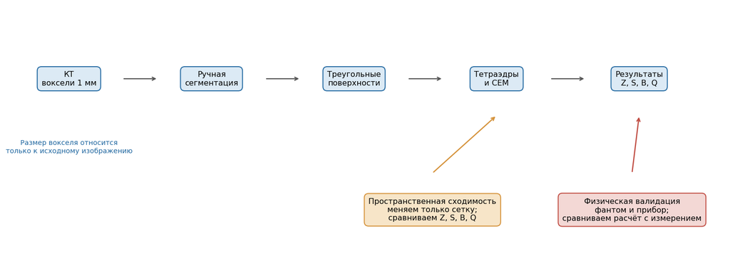

**Рисунок 9.** Место двух валидаций в расчётной цепочке. Размер вокселя относится к исходному изображению; после него возникают отдельные этапы сегментации, построения поверхностей, тетраэдрализации и контактной модели. Пространственная проверка сравнивает решения на разных сетках, а физическая — расчёт с независимым измерением.

**Пространственная сходимость** означает устойчивость $Z$, $S$, $B$, $Q$ и различий между сборками при последовательном уточнении сетки. Проверять только $Z$ недостаточно: производная и небольшая разность двух близких сборок могут быть чувствительнее к дискретизации, чем сам импеданс. Если сеточная неопределённость попарной разности сравнима с преимуществом одной сборки, эту пару следует считать численно неразличимой.

Размер вокселя исходной КТ **1 мм не решает эту задачу**. Воксель задаёт шаг выборки интенсивности изображения. После КТ отдельно выполняются сегментация, построение треугольных поверхностей и заполнение областей тетраэдрами. Эти операции имеют собственные ошибки. Шаг КТ не гарантирует, что все тетраэдры имеют ребро 1 мм, что они имеют хорошую форму, что границы органов аппроксимированы с нужной точностью или что под диском диаметром 5 мм достаточно граничных элементов. Он тем более не задаёт численную границу ошибки $Z$ и его производных.

Указанный для действующей сетки размер 1 мм относится только к граничным рёбрам в радиусе 8 мм от центров электродов. Это локальная мера качества контактных площадок. Она позволила исправить грубое несовпадение площади и положения контактов, но не проверила сходимость решения во всём объёме и около границ сердца и лёгких. Большое общее число тетраэдров также не заменяет сравнение решений на разных сетках. Даже сошедшееся FEM-решение может расходиться с измерением при неверных сопротивлениях тканей, контактном импедансе, анатомических границах или модели прибора; поэтому размер вокселя не заменяет и физическую валидацию.

Выполненная локальная проверка использует ту же анатомию, те же контакты и те же 78 контрольных состояний, но уменьшает локальный предел ребра около электродов с 1,0 до 0,5 мм. Сопоставляются $Z$, $S$, $B$, $Q$ и порядок сборок. Рабочие критерии предварительной проверки: изменение $Z$ не более 1%; изменение $S$ и $B$ не более 2% текущего модуля плюс 0,5% общего масштаба соответствующей величины; изменение $Q$ не более 0,01; сохранение сборки с наибольшим $B$ и $Q$ для каждого компартмента. Эти пороги являются численными правилами данного исследования, а не точностью прибора.

| Показатель предварительной проверки | Результат |
| --- | --- |
| Сопоставленные состояния | 78 |
| Проверок метрик с превышением допуска | 0 |
| Максимальное относительное изменение Z | 0,0881% |
| Наибольшее отношение ошибки S к допуску | 0,139 |
| Наибольшее отношение ошибки B к допуску | 0,139 |
| Максимальное абсолютное изменение Q | 0,0005025 |
| Сборки с максимальными показателями сохранены | да |
| Полный порядок шести сборок сохранён | да |
| Решение по локальной проверке | пройден |

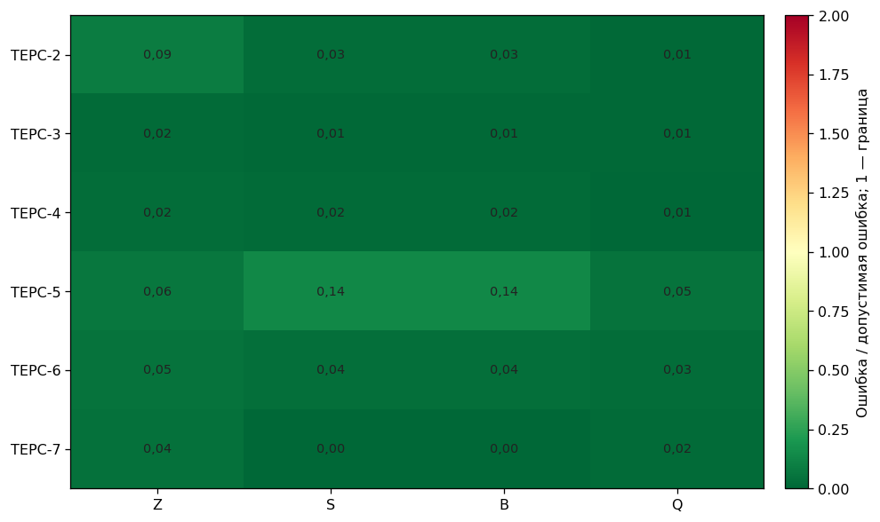

**Рисунок 10.** Максимальное по 78 состояниям отношение изменения показателя при переходе 1,0→0,5 мм к его рабочему допуску. Значение 1 соответствует границе критерия; значения больше 1 отмечают требование дополнительного уточнения. Цвет сравнивает ошибку с допуском внутри каждого показателя и не является картой физиологической чувствительности.

**Результат математической проверки:** все 780 сопоставлений прошли критерии; локальная контактная дискретизация прошла двухуровневую проверку на 78 состояниях, а полный порядок сборок сохранился. Этот результат не устанавливает сходимость объёмной сетки или границ компартментов.

Результат этого уровня допускает только вывод, что локальная дискретизация контактов устойчива при переходе 1,0→0,5 мм на проверенных состояниях. Для полной пространственной проверки затем требуются не менее трёх согласованных объёмных сеток с уточнением в объёме и около межкомпартментных границ. Обязательные состояния включают центр диапазона, его границы и углы, максимумы ошибок интерполяции, минимальные разрывы между сборками и области смены предпочтения. Ранжирование принимается, только если сеточная неопределённость меньше запаса между сборками.

**Физическая валидация** отвечает на другой вопрос: воспроизводит ли модель независимое измерение. Основной план включает паспортизацию прибора и контакта, многокомпартментный фантом с независимо измеренными геометрией и проводимостью при 50 кГц, контролируемое изменение одного компартмента, повторные установки электродов и сопоставление измеренных $Z$, $\Delta Z$ и $\Delta Z/\Delta\rho$ с расчётом. Пределы допустимой ошибки должны быть определены по неопределённости прибора, материалов, температуры, геометрии и установки до просмотра проверочной серии. План исполнения разделён на следующие этапы:

| Этап | Действие | Состояние и условие перехода |
| --- | --- | --- |
| S1 | Сравнить контактную дискретизацию 1,0 и 0,5 мм на 78 состояниях | выполнено; 780 из 780 проверок пройдены |
| S2 | При необходимости построить уровень 0,25 мм | сейчас не требуется; выполняется при нарушении S1 или введении более строгих критериев |
| S3 | Сопоставить не менее трёх объёмных сеток с уточнением около границ компартментов | обязательно до окончательного использования малых различий между сборками |
| P1 | Паспортизировать прибор и контактные условия | определить повторяемость и неопределённость до проверочной серии |
| P2–P3 | Провести калибровочную и независимую проверочную серии на многокомпартментном фантоме | принять пределы ошибок до просмотра проверочных данных |
| P4 | Выполнить повторные измерения на добровольцах | оценить воспроизводимость и перенос на живую анатомию; не использовать как единственную проверку производной целого компартмента |

Измерения на добровольце необходимы для оценки переноса на живую анатомию, но не заменяют фантомную проверку производной по сопротивлению целого компартмента. При дыхании и сердечном цикле одновременно меняются проводимость, кровенаполнение, объём, форма и положение органов; равномерно изменить только всё сердце или только оба лёгких при неизменных остальных параметрах невозможно. Поэтому согласие с физиологическим сигналом подтверждает суммарный отклик конкретного протокола, а не изолированную производную текущей модели.

Полный протокол, критерии перехода и ожидаемые артефакты зафиксированы в плане численной и физической валидации. До завершения пространственной и физической проверок численные предпочтения TEPC остаются результатом математической модели и служат для планирования следующих экспериментов.

## 11. Ограничения и последующий анализ

Отдельного измерения контактного импеданса и ошибок установки для этих координат нет. Модель не задаёт вероятностное распределение сопротивлений, независимость физиологических вариаций или общую шумовую дисперсию. Поэтому среднее по узлам не следует интерпретировать как математическое ожидание у популяции, а модельное преимущество сборки — как доказанное преимущество отношения сигнал/шум.

После основной серии можно выбрать сборки, интересные по целевому компартменту, и определить состояния, в которых предпочтение меняется. Для окончательного выбора потребуется оценить влияние размера контактов, их смещения и контактных условий, а также пространственную сходимость. Чувствительность к координатам и радиусу эквивалентной сферы будет отдельным вычислительным экспериментом. Переход от этих производных к функциям сердца требует дополнительных моделей и независимых проверок.

## Литература и происхождение данных

1. Metshein M., Gautier A., Larras B., Frappé A., John D., Cardiff B., Annus P., Land R., Martens O. *Study of Electrode Locations for Joint Acquisition of Impedance- and Electro-cardiography Signals*. 2021 43rd Annual International Conference of the IEEE Engineering in Medicine & Biology Society (EMBC), 7264–7267. [DOI: 10.1109/EMBC46164.2021.9629504](https://doi.org/10.1109/EMBC46164.2021.9629504); [проверенный полный текст](https://www.paperhost.org/proceedings/embs/EMBC21/files/1232.pdf).
2. IT’IS Foundation. *Tissue Properties Database V5.0*. [DOI: 10.13099/VIP21000-05-0, таблицы и коэффициенты дисперсии](https://itis.swiss/virtual-population/tissue-properties/downloads/database-v5-0). Использован ранее зафиксированный профиль 50 кГц этапа 40.08; коэффициенты и контрольные суммы сохранены в паспорте серии.
3. Авторские входные данные: шесть файлов TEPC-2–TEPC-7 из переданного архива; координаты ручного выбора на индивидуальной поверхности. Исходные КТ и расчётная сетка локальны. Наличие ноутбука без этих внешних артефактов не обеспечивает повторный FEM-расчёт.